# Risk Factor Analysis

## Outcome Variable

**Outcome Variable:** ever_stunted

## Predictor Variables

**Intervention Variable:** tr

**Adjustment Set:**

unadjusted

## Stratifying Variables

The analysis was stratified on these variable(s):

- agecat
- studyid
- country
- intXhfoodsec

## Data Summary

| agecat | studyid | country | intXhfoodsec | ever_stunted | n_cell | n |
| --- | --- | --- | --- | --- | --- | --- |
| 0-6 months | iLiNS_DYADM_LNS | MALAWI | Food Secure_0-6 months | 0 | 11 | 14 |
| 0-6 months | iLiNS_DYADM_LNS | MALAWI | Food Secure_0-6 months | 1 | 3 | 14 |
| 0-6 months | iLiNS_DYADM_LNS | MALAWI | Mildly Food Insecure_0-6 months | 0 | 2 | 3 |
| 0-6 months | iLiNS_DYADM_LNS | MALAWI | Mildly Food Insecure_0-6 months | 1 | 1 | 3 |
| 0-6 months | iLiNS_DYADM_LNS | MALAWI | Food Insecure_0-6 months | 0 | 5 | 7 |
| 0-6 months | iLiNS_DYADM_LNS | MALAWI | Food Insecure_0-6 months | 1 | 2 | 7 |
| 0-6 months | ki1000110-WASH-Bangladesh | BANGLADESH | Food Secure_0-6 months | 0 | 158 | 172 |
| 0-6 months | ki1000110-WASH-Bangladesh | BANGLADESH | Food Secure_0-6 months | 1 | 14 | 172 |
| 0-6 months | ki1000110-WASH-Bangladesh | BANGLADESH | Mildly Food Insecure_0-6 months | 0 | 12 | 12 |
| 0-6 months | ki1000110-WASH-Bangladesh | BANGLADESH | Mildly Food Insecure_0-6 months | 1 | 0 | 12 |
| 0-6 months | ki1000110-WASH-Bangladesh | BANGLADESH | Food Insecure_0-6 months | 0 | 39 | 48 |
| 0-6 months | ki1000110-WASH-Bangladesh | BANGLADESH | Food Insecure_0-6 months | 1 | 9 | 48 |
| 0-6 months | ki1148112-iLiNS-DOSE | MALAWI | Food Secure_0-6 months | 0 | 190 | 252 |
| 0-6 months | ki1148112-iLiNS-DOSE | MALAWI | Food Secure_0-6 months | 1 | 62 | 252 |
| 0-6 months | ki1148112-iLiNS-DOSE | MALAWI | Mildly Food Insecure_0-6 months | 0 | 52 | 86 |
| 0-6 months | ki1148112-iLiNS-DOSE | MALAWI | Mildly Food Insecure_0-6 months | 1 | 34 | 86 |
| 0-6 months | ki1148112-iLiNS-DOSE | MALAWI | Food Insecure_0-6 months | 0 | 547 | 777 |
| 0-6 months | ki1148112-iLiNS-DOSE | MALAWI | Food Insecure_0-6 months | 1 | 230 | 777 |
| 0-6 months | ki1148112-iLiNS-DYAD-M | MALAWI | Food Secure_0-6 months | 0 | 17 | 23 |
| 0-6 months | ki1148112-iLiNS-DYAD-M | MALAWI | Food Secure_0-6 months | 1 | 6 | 23 |
| 0-6 months | ki1148112-iLiNS-DYAD-M | MALAWI | Mildly Food Insecure_0-6 months | 0 | 4 | 6 |
| 0-6 months | ki1148112-iLiNS-DYAD-M | MALAWI | Mildly Food Insecure_0-6 months | 1 | 2 | 6 |
| 0-6 months | ki1148112-iLiNS-DYAD-M | MALAWI | Food Insecure_0-6 months | 0 | 10 | 14 |
| 0-6 months | ki1148112-iLiNS-DYAD-M | MALAWI | Food Insecure_0-6 months | 1 | 4 | 14 |
| 0-6 months | kiGH5241-JiVitA-3 | BANGLADESH | Food Secure_0-6 months | 0 | 10706 | 13718 |
| 0-6 months | kiGH5241-JiVitA-3 | BANGLADESH | Food Secure_0-6 months | 1 | 3012 | 13718 |
| 0-6 months | kiGH5241-JiVitA-3 | BANGLADESH | Mildly Food Insecure_0-6 months | 0 | 6776 | 9226 |
| 0-6 months | kiGH5241-JiVitA-3 | BANGLADESH | Mildly Food Insecure_0-6 months | 1 | 2450 | 9226 |
| 0-6 months | kiGH5241-JiVitA-3 | BANGLADESH | Food Insecure_0-6 months | 0 | 3238 | 4582 |
| 0-6 months | kiGH5241-JiVitA-3 | BANGLADESH | Food Insecure_0-6 months | 1 | 1344 | 4582 |
| 0-6 months | kiGH5241-JiVitA-4 | BANGLADESH | Food Secure_0-6 months | 0 | 3450 | 4628 |
| 0-6 months | kiGH5241-JiVitA-4 | BANGLADESH | Food Secure_0-6 months | 1 | 1178 | 4628 |
| 0-6 months | kiGH5241-JiVitA-4 | BANGLADESH | Mildly Food Insecure_0-6 months | 0 | 2420 | 3274 |
| 0-6 months | kiGH5241-JiVitA-4 | BANGLADESH | Mildly Food Insecure_0-6 months | 1 | 854 | 3274 |
| 0-6 months | kiGH5241-JiVitA-4 | BANGLADESH | Food Insecure_0-6 months | 0 | 918 | 1172 |
| 0-6 months | kiGH5241-JiVitA-4 | BANGLADESH | Food Insecure_0-6 months | 1 | 254 | 1172 |
| 6-24 months | iLiNS_DYADM_LNS | MALAWI | Food Secure_6-24 months | 0 | 66 | 82 |
| 6-24 months | iLiNS_DYADM_LNS | MALAWI | Food Secure_6-24 months | 1 | 16 | 82 |
| 6-24 months | iLiNS_DYADM_LNS | MALAWI | Mildly Food Insecure_6-24 months | 0 | 42 | 45 |
| 6-24 months | iLiNS_DYADM_LNS | MALAWI | Mildly Food Insecure_6-24 months | 1 | 3 | 45 |
| 6-24 months | iLiNS_DYADM_LNS | MALAWI | Food Insecure_6-24 months | 0 | 95 | 118 |
| 6-24 months | iLiNS_DYADM_LNS | MALAWI | Food Insecure_6-24 months | 1 | 23 | 118 |
| 6-24 months | ki1000110-WASH-Bangladesh | BANGLADESH | Food Secure_6-24 months | 0 | 2153 | 3313 |
| 6-24 months | ki1000110-WASH-Bangladesh | BANGLADESH | Food Secure_6-24 months | 1 | 1160 | 3313 |
| 6-24 months | ki1000110-WASH-Bangladesh | BANGLADESH | Mildly Food Insecure_6-24 months | 0 | 261 | 420 |
| 6-24 months | ki1000110-WASH-Bangladesh | BANGLADESH | Mildly Food Insecure_6-24 months | 1 | 159 | 420 |
| 6-24 months | ki1000110-WASH-Bangladesh | BANGLADESH | Food Insecure_6-24 months | 0 | 547 | 1050 |
| 6-24 months | ki1000110-WASH-Bangladesh | BANGLADESH | Food Insecure_6-24 months | 1 | 503 | 1050 |
| 6-24 months | ki1148112-iLiNS-DOSE | MALAWI | Food Secure_6-24 months | 0 | 205 | 319 |
| 6-24 months | ki1148112-iLiNS-DOSE | MALAWI | Food Secure_6-24 months | 1 | 114 | 319 |
| 6-24 months | ki1148112-iLiNS-DOSE | MALAWI | Mildly Food Insecure_6-24 months | 0 | 69 | 109 |
| 6-24 months | ki1148112-iLiNS-DOSE | MALAWI | Mildly Food Insecure_6-24 months | 1 | 40 | 109 |
| 6-24 months | ki1148112-iLiNS-DOSE | MALAWI | Food Insecure_6-24 months | 0 | 545 | 959 |
| 6-24 months | ki1148112-iLiNS-DOSE | MALAWI | Food Insecure_6-24 months | 1 | 414 | 959 |
| 6-24 months | ki1148112-iLiNS-DYAD-M | MALAWI | Food Secure_6-24 months | 0 | 97 | 122 |
| 6-24 months | ki1148112-iLiNS-DYAD-M | MALAWI | Food Secure_6-24 months | 1 | 25 | 122 |
| 6-24 months | ki1148112-iLiNS-DYAD-M | MALAWI | Mildly Food Insecure_6-24 months | 0 | 56 | 67 |
| 6-24 months | ki1148112-iLiNS-DYAD-M | MALAWI | Mildly Food Insecure_6-24 months | 1 | 11 | 67 |
| 6-24 months | ki1148112-iLiNS-DYAD-M | MALAWI | Food Insecure_6-24 months | 0 | 154 | 197 |
| 6-24 months | ki1148112-iLiNS-DYAD-M | MALAWI | Food Insecure_6-24 months | 1 | 43 | 197 |
| 6-24 months | kiGH5241-JiVitA-3 | BANGLADESH | Food Secure_6-24 months | 0 | 8072 | 9585 |
| 6-24 months | kiGH5241-JiVitA-3 | BANGLADESH | Food Secure_6-24 months | 1 | 1513 | 9585 |
| 6-24 months | kiGH5241-JiVitA-3 | BANGLADESH | Mildly Food Insecure_6-24 months | 0 | 4580 | 5630 |
| 6-24 months | kiGH5241-JiVitA-3 | BANGLADESH | Mildly Food Insecure_6-24 months | 1 | 1050 | 5630 |
| 6-24 months | kiGH5241-JiVitA-3 | BANGLADESH | Food Insecure_6-24 months | 0 | 2014 | 2519 |
| 6-24 months | kiGH5241-JiVitA-3 | BANGLADESH | Food Insecure_6-24 months | 1 | 505 | 2519 |
| 6-24 months | kiGH5241-JiVitA-4 | BANGLADESH | Food Secure_6-24 months | 0 | 2356 | 3230 |
| 6-24 months | kiGH5241-JiVitA-4 | BANGLADESH | Food Secure_6-24 months | 1 | 874 | 3230 |
| 6-24 months | kiGH5241-JiVitA-4 | BANGLADESH | Mildly Food Insecure_6-24 months | 0 | 1680 | 2306 |
| 6-24 months | kiGH5241-JiVitA-4 | BANGLADESH | Mildly Food Insecure_6-24 months | 1 | 626 | 2306 |
| 6-24 months | kiGH5241-JiVitA-4 | BANGLADESH | Food Insecure_6-24 months | 0 | 635 | 883 |
| 6-24 months | kiGH5241-JiVitA-4 | BANGLADESH | Food Insecure_6-24 months | 1 | 248 | 883 |

The following strata were considered:

- agecat: 0-6 months, studyid: iLiNS_DYADM_LNS, country: MALAWI, intXhfoodsec: Food Insecure_0-6 months
- agecat: 0-6 months, studyid: iLiNS_DYADM_LNS, country: MALAWI, intXhfoodsec: Food Secure_0-6 months
- agecat: 0-6 months, studyid: iLiNS_DYADM_LNS, country: MALAWI, intXhfoodsec: Mildly Food Insecure_0-6 months
- agecat: 0-6 months, studyid: ki1000110-WASH-Bangladesh, country: BANGLADESH, intXhfoodsec: Food Insecure_0-6 months
- agecat: 0-6 months, studyid: ki1000110-WASH-Bangladesh, country: BANGLADESH, intXhfoodsec: Food Secure_0-6 months
- agecat: 0-6 months, studyid: ki1000110-WASH-Bangladesh, country: BANGLADESH, intXhfoodsec: Mildly Food Insecure_0-6 months
- agecat: 0-6 months, studyid: ki1148112-iLiNS-DOSE, country: MALAWI, intXhfoodsec: Food Insecure_0-6 months
- agecat: 0-6 months, studyid: ki1148112-iLiNS-DOSE, country: MALAWI, intXhfoodsec: Food Secure_0-6 months
- agecat: 0-6 months, studyid: ki1148112-iLiNS-DOSE, country: MALAWI, intXhfoodsec: Mildly Food Insecure_0-6 months
- agecat: 0-6 months, studyid: ki1148112-iLiNS-DYAD-M, country: MALAWI, intXhfoodsec: Food Insecure_0-6 months
- agecat: 0-6 months, studyid: ki1148112-iLiNS-DYAD-M, country: MALAWI, intXhfoodsec: Food Secure_0-6 months
- agecat: 0-6 months, studyid: ki1148112-iLiNS-DYAD-M, country: MALAWI, intXhfoodsec: Mildly Food Insecure_0-6 months
- agecat: 0-6 months, studyid: kiGH5241-JiVitA-3, country: BANGLADESH, intXhfoodsec: Food Insecure_0-6 months
- agecat: 0-6 months, studyid: kiGH5241-JiVitA-3, country: BANGLADESH, intXhfoodsec: Food Secure_0-6 months
- agecat: 0-6 months, studyid: kiGH5241-JiVitA-3, country: BANGLADESH, intXhfoodsec: Mildly Food Insecure_0-6 months
- agecat: 0-6 months, studyid: kiGH5241-JiVitA-4, country: BANGLADESH, intXhfoodsec: Food Insecure_0-6 months
- agecat: 0-6 months, studyid: kiGH5241-JiVitA-4, country: BANGLADESH, intXhfoodsec: Food Secure_0-6 months
- agecat: 0-6 months, studyid: kiGH5241-JiVitA-4, country: BANGLADESH, intXhfoodsec: Mildly Food Insecure_0-6 months
- agecat: 6-24 months, studyid: iLiNS_DYADM_LNS, country: MALAWI, intXhfoodsec: Food Insecure_6-24 months
- agecat: 6-24 months, studyid: iLiNS_DYADM_LNS, country: MALAWI, intXhfoodsec: Food Secure_6-24 months
- agecat: 6-24 months, studyid: iLiNS_DYADM_LNS, country: MALAWI, intXhfoodsec: Mildly Food Insecure_6-24 months
- agecat: 6-24 months, studyid: ki1000110-WASH-Bangladesh, country: BANGLADESH, intXhfoodsec: Food Insecure_6-24 months
- agecat: 6-24 months, studyid: ki1000110-WASH-Bangladesh, country: BANGLADESH, intXhfoodsec: Food Secure_6-24 months
- agecat: 6-24 months, studyid: ki1000110-WASH-Bangladesh, country: BANGLADESH, intXhfoodsec: Mildly Food Insecure_6-24 months
- agecat: 6-24 months, studyid: ki1148112-iLiNS-DOSE, country: MALAWI, intXhfoodsec: Food Insecure_6-24 months
- agecat: 6-24 months, studyid: ki1148112-iLiNS-DOSE, country: MALAWI, intXhfoodsec: Food Secure_6-24 months
- agecat: 6-24 months, studyid: ki1148112-iLiNS-DOSE, country: MALAWI, intXhfoodsec: Mildly Food Insecure_6-24 months
- agecat: 6-24 months, studyid: ki1148112-iLiNS-DYAD-M, country: MALAWI, intXhfoodsec: Food Insecure_6-24 months
- agecat: 6-24 months, studyid: ki1148112-iLiNS-DYAD-M, country: MALAWI, intXhfoodsec: Food Secure_6-24 months
- agecat: 6-24 months, studyid: ki1148112-iLiNS-DYAD-M, country: MALAWI, intXhfoodsec: Mildly Food Insecure_6-24 months
- agecat: 6-24 months, studyid: kiGH5241-JiVitA-3, country: BANGLADESH, intXhfoodsec: Food Insecure_6-24 months
- agecat: 6-24 months, studyid: kiGH5241-JiVitA-3, country: BANGLADESH, intXhfoodsec: Food Secure_6-24 months
- agecat: 6-24 months, studyid: kiGH5241-JiVitA-3, country: BANGLADESH, intXhfoodsec: Mildly Food Insecure_6-24 months
- agecat: 6-24 months, studyid: kiGH5241-JiVitA-4, country: BANGLADESH, intXhfoodsec: Food Insecure_6-24 months
- agecat: 6-24 months, studyid: kiGH5241-JiVitA-4, country: BANGLADESH, intXhfoodsec: Food Secure_6-24 months
- agecat: 6-24 months, studyid: kiGH5241-JiVitA-4, country: BANGLADESH, intXhfoodsec: Mildly Food Insecure_6-24 months

### Dropped Strata

Some strata were dropped due to rare outcomes:

- agecat: 0-6 months, studyid: iLiNS_DYADM_LNS, country: MALAWI, intXhfoodsec: Food Secure_0-6 months
- agecat: 0-6 months, studyid: iLiNS_DYADM_LNS, country: MALAWI, intXhfoodsec: Mildly Food Insecure_0-6 months
- agecat: 0-6 months, studyid: iLiNS_DYADM_LNS, country: MALAWI, intXhfoodsec: Food Insecure_0-6 months
- agecat: 0-6 months, studyid: ki1000110-WASH-Bangladesh, country: BANGLADESH, intXhfoodsec: Mildly Food Insecure_0-6 months
- agecat: 0-6 months, studyid: ki1148112-iLiNS-DYAD-M, country: MALAWI, intXhfoodsec: Mildly Food Insecure_0-6 months
- agecat: 0-6 months, studyid: ki1148112-iLiNS-DYAD-M, country: MALAWI, intXhfoodsec: Food Insecure_0-6 months
- agecat: 6-24 months, studyid: iLiNS_DYADM_LNS, country: MALAWI, intXhfoodsec: Mildly Food Insecure_6-24 months

## Methods Detail

We’re interested in the causal parameters $E[Y_a]$ for all values of $a \in \mathcal{A}$. These parameters represent the mean outcome if, possibly contrary to fact, we intervened to set all units to have $A=a$. Under the randomization and positivity assumptions, these are identified by the statistical parameters $\psi_a=E_W[E_{Y|A,W}(Y|A=a,W)]$. In addition, we’re interested in the mean of $Y$, $E[Y]$ under no intervention (the observed mean). We will estimate these parameters by using SuperLearner to fit the relevant likelihood factors – $E_{Y|A,W}(Y|A=a,W)$ and $p(A=a|W)$, and then updating our likelihood fit using a joint TMLE.

For unadjusted analyses ($W=\{\}$), initial likelihoods were estimated using Lrnr_glm to estimate the simple $E(Y|A)$ and Lrnr_mean to estimate $p(A)$. For adjusted analyses, a small library containing Lrnr_glmnet, Lrnr_xgboost, and Lrnr_mean was used.

Having estimated these parameters, we will then use the delta method to estimate relative risks and attributable risks relative to a prespecified baseline level of $A$.

# Results Detail

## Results Plots

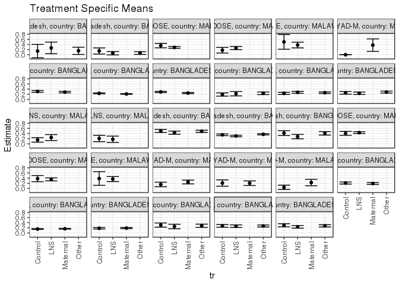

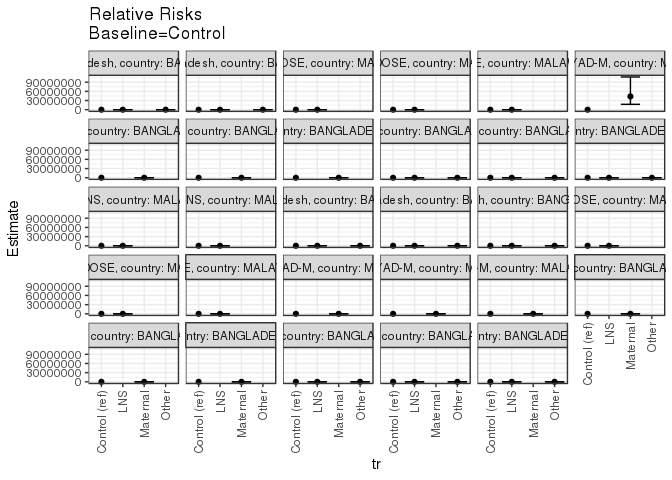

[figure not shown]

[figure not shown]

## Results Table

### Parameter: TSM

| agecat | studyid | country | intXhfoodsec | intervention_level | baseline_level | estimate | ci_lower | ci_upper |
| --- | --- | --- | --- | --- | --- | --- | --- | --- |
| 0-6 months | ki1000110-WASH-Bangladesh | BANGLADESH | Food Secure_0-6 months | Control | NA | 0.1470588 | 0.0276655 | 0.2664521 |
| 0-6 months | ki1000110-WASH-Bangladesh | BANGLADESH | Food Secure_0-6 months | LNS | NA | 0.0600000 | -0.0060190 | 0.1260190 |
| 0-6 months | ki1000110-WASH-Bangladesh | BANGLADESH | Food Secure_0-6 months | Other | NA | 0.0681818 | 0.0153649 | 0.1209987 |
| 0-6 months | ki1000110-WASH-Bangladesh | BANGLADESH | Food Insecure_0-6 months | Control | NA | 0.1428571 | -0.1191109 | 0.4048252 |
| 0-6 months | ki1000110-WASH-Bangladesh | BANGLADESH | Food Insecure_0-6 months | LNS | NA | 0.2666667 | 0.0405101 | 0.4928232 |
| 0-6 months | ki1000110-WASH-Bangladesh | BANGLADESH | Food Insecure_0-6 months | Other | NA | 0.1538462 | 0.0136936 | 0.2939987 |
| 0-6 months | ki1148112-iLiNS-DOSE | MALAWI | Food Secure_0-6 months | Control | NA | 0.1777778 | 0.0658498 | 0.2897057 |
| 0-6 months | ki1148112-iLiNS-DOSE | MALAWI | Food Secure_0-6 months | LNS | NA | 0.2608696 | 0.2009321 | 0.3208071 |
| 0-6 months | ki1148112-iLiNS-DOSE | MALAWI | Mildly Food Insecure_0-6 months | Control | NA | 0.5000000 | 0.2154443 | 0.7845557 |
| 0-6 months | ki1148112-iLiNS-DOSE | MALAWI | Mildly Food Insecure_0-6 months | LNS | NA | 0.3783784 | 0.2672313 | 0.4895255 |
| 0-6 months | ki1148112-iLiNS-DOSE | MALAWI | Food Insecure_0-6 months | Control | NA | 0.3559322 | 0.2694879 | 0.4423765 |
| 0-6 months | ki1148112-iLiNS-DOSE | MALAWI | Food Insecure_0-6 months | LNS | NA | 0.2852807 | 0.2507831 | 0.3197783 |
| 0-6 months | ki1148112-iLiNS-DYAD-M | MALAWI | Food Secure_0-6 months | Control | NA | 0.0000000 | 0.0000000 | 0.0000000 |
| 0-6 months | ki1148112-iLiNS-DYAD-M | MALAWI | Food Secure_0-6 months | Maternal | NA | 0.3750000 | 0.1324528 | 0.6175472 |
| 0-6 months | kiGH5241-JiVitA-3 | BANGLADESH | Food Secure_0-6 months | Control | NA | 0.2315728 | 0.2147673 | 0.2483784 |
| 0-6 months | kiGH5241-JiVitA-3 | BANGLADESH | Food Secure_0-6 months | Maternal | NA | 0.2074421 | 0.1927047 | 0.2221796 |
| 0-6 months | kiGH5241-JiVitA-3 | BANGLADESH | Mildly Food Insecure_0-6 months | Control | NA | 0.2877442 | 0.2647890 | 0.3106994 |
| 0-6 months | kiGH5241-JiVitA-3 | BANGLADESH | Mildly Food Insecure_0-6 months | Maternal | NA | 0.2443880 | 0.2217537 | 0.2670222 |
| 0-6 months | kiGH5241-JiVitA-3 | BANGLADESH | Food Insecure_0-6 months | Control | NA | 0.3066079 | 0.2712939 | 0.3419219 |
| 0-6 months | kiGH5241-JiVitA-3 | BANGLADESH | Food Insecure_0-6 months | Maternal | NA | 0.2802768 | 0.2489291 | 0.3116246 |
| 0-6 months | kiGH5241-JiVitA-4 | BANGLADESH | Food Secure_0-6 months | Control | NA | 0.2320261 | 0.1906645 | 0.2733877 |
| 0-6 months | kiGH5241-JiVitA-4 | BANGLADESH | Food Secure_0-6 months | LNS | NA | 0.2717391 | 0.2327801 | 0.3106982 |
| 0-6 months | kiGH5241-JiVitA-4 | BANGLADESH | Food Secure_0-6 months | Other | NA | 0.2570888 | 0.2261657 | 0.2880120 |
| 0-6 months | kiGH5241-JiVitA-4 | BANGLADESH | Mildly Food Insecure_0-6 months | Control | NA | 0.2512563 | 0.2003787 | 0.3021339 |
| 0-6 months | kiGH5241-JiVitA-4 | BANGLADESH | Mildly Food Insecure_0-6 months | LNS | NA | 0.2354212 | 0.1904644 | 0.2803779 |
| 0-6 months | kiGH5241-JiVitA-4 | BANGLADESH | Mildly Food Insecure_0-6 months | Other | NA | 0.2809278 | 0.2427726 | 0.3190831 |
| 0-6 months | kiGH5241-JiVitA-4 | BANGLADESH | Food Insecure_0-6 months | Control | NA | 0.1863354 | 0.1233434 | 0.2493274 |
| 0-6 months | kiGH5241-JiVitA-4 | BANGLADESH | Food Insecure_0-6 months | LNS | NA | 0.2180451 | 0.1333281 | 0.3027622 |
| 0-6 months | kiGH5241-JiVitA-4 | BANGLADESH | Food Insecure_0-6 months | Other | NA | 0.2328767 | 0.1819193 | 0.2838342 |
| 6-24 months | iLiNS_DYADM_LNS | MALAWI | Food Secure_6-24 months | Control | NA | 0.2093023 | 0.0854419 | 0.3331627 |
| 6-24 months | iLiNS_DYADM_LNS | MALAWI | Food Secure_6-24 months | LNS | NA | 0.1794872 | 0.0571482 | 0.3018262 |
| 6-24 months | iLiNS_DYADM_LNS | MALAWI | Food Insecure_6-24 months | Control | NA | 0.1538462 | 0.0657600 | 0.2419323 |
| 6-24 months | iLiNS_DYADM_LNS | MALAWI | Food Insecure_6-24 months | LNS | NA | 0.2452830 | 0.1289551 | 0.3616110 |
| 6-24 months | ki1000110-WASH-Bangladesh | BANGLADESH | Food Secure_6-24 months | Control | NA | 0.3526448 | 0.3194062 | 0.3858835 |
| 6-24 months | ki1000110-WASH-Bangladesh | BANGLADESH | Food Secure_6-24 months | LNS | NA | 0.3056872 | 0.2746016 | 0.3367728 |
| 6-24 months | ki1000110-WASH-Bangladesh | BANGLADESH | Food Secure_6-24 months | Other | NA | 0.3713433 | 0.3482013 | 0.3944853 |
| 6-24 months | ki1000110-WASH-Bangladesh | BANGLADESH | Mildly Food Insecure_6-24 months | Control | NA | 0.4190476 | 0.3245604 | 0.5135348 |
| 6-24 months | ki1000110-WASH-Bangladesh | BANGLADESH | Mildly Food Insecure_6-24 months | LNS | NA | 0.2818182 | 0.1976455 | 0.3659908 |
| 6-24 months | ki1000110-WASH-Bangladesh | BANGLADESH | Mildly Food Insecure_6-24 months | Other | NA | 0.4097561 | 0.3423550 | 0.4771572 |
| 6-24 months | ki1000110-WASH-Bangladesh | BANGLADESH | Food Insecure_6-24 months | Control | NA | 0.5018587 | 0.4420801 | 0.5616374 |
| 6-24 months | ki1000110-WASH-Bangladesh | BANGLADESH | Food Insecure_6-24 months | LNS | NA | 0.4349594 | 0.3729793 | 0.4969394 |
| 6-24 months | ki1000110-WASH-Bangladesh | BANGLADESH | Food Insecure_6-24 months | Other | NA | 0.4878505 | 0.4454745 | 0.5302265 |
| 6-24 months | ki1148112-iLiNS-DOSE | MALAWI | Food Secure_6-24 months | Control | NA | 0.3809524 | 0.2608485 | 0.5010562 |
| 6-24 months | ki1148112-iLiNS-DOSE | MALAWI | Food Secure_6-24 months | LNS | NA | 0.3515625 | 0.2929831 | 0.4101419 |
| 6-24 months | ki1148112-iLiNS-DOSE | MALAWI | Mildly Food Insecure_6-24 months | Control | NA | 0.3846154 | 0.1189320 | 0.6502988 |
| 6-24 months | ki1148112-iLiNS-DOSE | MALAWI | Mildly Food Insecure_6-24 months | LNS | NA | 0.3645833 | 0.2678577 | 0.4613090 |
| 6-24 months | ki1148112-iLiNS-DOSE | MALAWI | Food Insecure_6-24 months | Control | NA | 0.4088050 | 0.3323511 | 0.4852589 |
| 6-24 months | ki1148112-iLiNS-DOSE | MALAWI | Food Insecure_6-24 months | LNS | NA | 0.4362500 | 0.4018672 | 0.4706328 |
| 6-24 months | ki1148112-iLiNS-DYAD-M | MALAWI | Food Secure_6-24 months | Control | NA | 0.2093023 | 0.0861954 | 0.3324093 |
| 6-24 months | ki1148112-iLiNS-DYAD-M | MALAWI | Food Secure_6-24 months | Maternal | NA | 0.2025316 | 0.1129520 | 0.2921113 |
| 6-24 months | ki1148112-iLiNS-DYAD-M | MALAWI | Mildly Food Insecure_6-24 months | Control | NA | 0.0434783 | -0.0404935 | 0.1274500 |
| 6-24 months | ki1148112-iLiNS-DYAD-M | MALAWI | Mildly Food Insecure_6-24 months | Maternal | NA | 0.2272727 | 0.1025131 | 0.3520323 |
| 6-24 months | ki1148112-iLiNS-DYAD-M | MALAWI | Food Insecure_6-24 months | Control | NA | 0.1538462 | 0.0659106 | 0.2417817 |
| 6-24 months | ki1148112-iLiNS-DYAD-M | MALAWI | Food Insecure_6-24 months | Maternal | NA | 0.2500000 | 0.1759429 | 0.3240571 |
| 6-24 months | kiGH5241-JiVitA-3 | BANGLADESH | Food Secure_6-24 months | Control | NA | 0.1531915 | 0.1366702 | 0.1697128 |
| 6-24 months | kiGH5241-JiVitA-3 | BANGLADESH | Food Secure_6-24 months | Maternal | NA | 0.1623337 | 0.1463982 | 0.1782691 |
| 6-24 months | kiGH5241-JiVitA-3 | BANGLADESH | Mildly Food Insecure_6-24 months | Control | NA | 0.1836041 | 0.1532946 | 0.2139136 |
| 6-24 months | kiGH5241-JiVitA-3 | BANGLADESH | Mildly Food Insecure_6-24 months | Maternal | NA | 0.1890714 | 0.1667463 | 0.2113965 |
| 6-24 months | kiGH5241-JiVitA-3 | BANGLADESH | Food Insecure_6-24 months | Control | NA | 0.2094325 | 0.1692453 | 0.2496196 |
| 6-24 months | kiGH5241-JiVitA-3 | BANGLADESH | Food Insecure_6-24 months | Maternal | NA | 0.1916404 | 0.1557355 | 0.2275452 |
| 6-24 months | kiGH5241-JiVitA-4 | BANGLADESH | Food Secure_6-24 months | Control | NA | 0.2753129 | 0.2243652 | 0.3262605 |
| 6-24 months | kiGH5241-JiVitA-4 | BANGLADESH | Food Secure_6-24 months | LNS | NA | 0.2638889 | 0.2135917 | 0.3141860 |
| 6-24 months | kiGH5241-JiVitA-4 | BANGLADESH | Food Secure_6-24 months | Other | NA | 0.2716880 | 0.2329253 | 0.3104506 |
| 6-24 months | kiGH5241-JiVitA-4 | BANGLADESH | Mildly Food Insecure_6-24 months | Control | NA | 0.2993311 | 0.2401646 | 0.3584976 |
| 6-24 months | kiGH5241-JiVitA-4 | BANGLADESH | Mildly Food Insecure_6-24 months | LNS | NA | 0.2378049 | 0.1862058 | 0.2894039 |
| 6-24 months | kiGH5241-JiVitA-4 | BANGLADESH | Mildly Food Insecure_6-24 months | Other | NA | 0.2766160 | 0.2324193 | 0.3208127 |
| 6-24 months | kiGH5241-JiVitA-4 | BANGLADESH | Food Insecure_6-24 months | Control | NA | 0.3070866 | 0.2266332 | 0.3875400 |
| 6-24 months | kiGH5241-JiVitA-4 | BANGLADESH | Food Insecure_6-24 months | LNS | NA | 0.2512077 | 0.1620888 | 0.3403266 |
| 6-24 months | kiGH5241-JiVitA-4 | BANGLADESH | Food Insecure_6-24 months | Other | NA | 0.2796209 | 0.2163221 | 0.3429196 |

### Parameter: E(Y)

| agecat | studyid | country | intXhfoodsec | intervention_level | baseline_level | estimate | ci_lower | ci_upper |
| --- | --- | --- | --- | --- | --- | --- | --- | --- |
| 0-6 months | ki1000110-WASH-Bangladesh | BANGLADESH | Food Secure_0-6 months | NA | NA | 0.0813953 | 0.0404114 | 0.1223793 |
| 0-6 months | ki1000110-WASH-Bangladesh | BANGLADESH | Food Insecure_0-6 months | NA | NA | 0.1875000 | 0.0759135 | 0.2990865 |
| 0-6 months | ki1148112-iLiNS-DOSE | MALAWI | Food Secure_0-6 months | NA | NA | 0.2460317 | 0.1927494 | 0.2993141 |
| 0-6 months | ki1148112-iLiNS-DOSE | MALAWI | Mildly Food Insecure_0-6 months | NA | NA | 0.3953488 | 0.2914092 | 0.4992885 |
| 0-6 months | ki1148112-iLiNS-DOSE | MALAWI | Food Insecure_0-6 months | NA | NA | 0.2960103 | 0.2638919 | 0.3281287 |
| 0-6 months | ki1148112-iLiNS-DYAD-M | MALAWI | Food Secure_0-6 months | NA | NA | 0.2608696 | 0.0773810 | 0.4443581 |
| 0-6 months | kiGH5241-JiVitA-3 | BANGLADESH | Food Secure_0-6 months | NA | NA | 0.2195655 | 0.2083210 | 0.2308101 |
| 0-6 months | kiGH5241-JiVitA-3 | BANGLADESH | Mildly Food Insecure_0-6 months | NA | NA | 0.2655539 | 0.2493628 | 0.2817449 |
| 0-6 months | kiGH5241-JiVitA-3 | BANGLADESH | Food Insecure_0-6 months | NA | NA | 0.2933217 | 0.2697137 | 0.3169297 |
| 0-6 months | kiGH5241-JiVitA-4 | BANGLADESH | Food Secure_0-6 months | NA | NA | 0.2545376 | 0.2336424 | 0.2754328 |
| 0-6 months | kiGH5241-JiVitA-4 | BANGLADESH | Mildly Food Insecure_0-6 months | NA | NA | 0.2608430 | 0.2354079 | 0.2862782 |
| 0-6 months | kiGH5241-JiVitA-4 | BANGLADESH | Food Insecure_0-6 months | NA | NA | 0.2167235 | 0.1804186 | 0.2530285 |
| 6-24 months | iLiNS_DYADM_LNS | MALAWI | Food Secure_6-24 months | NA | NA | 0.1951220 | 0.1078781 | 0.2823658 |
| 6-24 months | iLiNS_DYADM_LNS | MALAWI | Food Insecure_6-24 months | NA | NA | 0.1949153 | 0.1231360 | 0.2666945 |
| 6-24 months | ki1000110-WASH-Bangladesh | BANGLADESH | Food Secure_6-24 months | NA | NA | 0.3501358 | 0.3338904 | 0.3663813 |
| 6-24 months | ki1000110-WASH-Bangladesh | BANGLADESH | Mildly Food Insecure_6-24 months | NA | NA | 0.3785714 | 0.3321295 | 0.4250134 |
| 6-24 months | ki1000110-WASH-Bangladesh | BANGLADESH | Food Insecure_6-24 months | NA | NA | 0.4790476 | 0.4488169 | 0.5092784 |
| 6-24 months | ki1148112-iLiNS-DOSE | MALAWI | Food Secure_6-24 months | NA | NA | 0.3573668 | 0.3046956 | 0.4100380 |
| 6-24 months | ki1148112-iLiNS-DOSE | MALAWI | Mildly Food Insecure_6-24 months | NA | NA | 0.3669725 | 0.2760724 | 0.4578726 |
| 6-24 months | ki1148112-iLiNS-DOSE | MALAWI | Food Insecure_6-24 months | NA | NA | 0.4316997 | 0.4003347 | 0.4630647 |
| 6-24 months | ki1148112-iLiNS-DYAD-M | MALAWI | Food Secure_6-24 months | NA | NA | 0.2049180 | 0.1324782 | 0.2773579 |
| 6-24 months | ki1148112-iLiNS-DYAD-M | MALAWI | Mildly Food Insecure_6-24 months | NA | NA | 0.1641791 | 0.0748091 | 0.2535491 |
| 6-24 months | ki1148112-iLiNS-DYAD-M | MALAWI | Food Insecure_6-24 months | NA | NA | 0.2182741 | 0.1604447 | 0.2761035 |
| 6-24 months | kiGH5241-JiVitA-3 | BANGLADESH | Food Secure_6-24 months | NA | NA | 0.1578508 | 0.1463794 | 0.1693222 |
| 6-24 months | kiGH5241-JiVitA-3 | BANGLADESH | Mildly Food Insecure_6-24 months | NA | NA | 0.1865009 | 0.1679782 | 0.2050236 |
| 6-24 months | kiGH5241-JiVitA-3 | BANGLADESH | Food Insecure_6-24 months | NA | NA | 0.2004764 | 0.1735209 | 0.2274318 |
| 6-24 months | kiGH5241-JiVitA-4 | BANGLADESH | Food Secure_6-24 months | NA | NA | 0.2705882 | 0.2442905 | 0.2968860 |
| 6-24 months | kiGH5241-JiVitA-4 | BANGLADESH | Mildly Food Insecure_6-24 months | NA | NA | 0.2714657 | 0.2421533 | 0.3007781 |
| 6-24 months | kiGH5241-JiVitA-4 | BANGLADESH | Food Insecure_6-24 months | NA | NA | 0.2808607 | 0.2374012 | 0.3243202 |

### Parameter: RR

| agecat | studyid | country | intXhfoodsec | intervention_level | baseline_level | estimate | ci_lower | ci_upper |
| --- | --- | --- | --- | --- | --- | --- | --- | --- |
| 0-6 months | ki1000110-WASH-Bangladesh | BANGLADESH | Food Secure_0-6 months | Control | Control | 1.0000000 | 1.0000000 | 1.0000000 |
| 0-6 months | ki1000110-WASH-Bangladesh | BANGLADESH | Food Secure_0-6 months | LNS | Control | 0.4080000 | 0.1039435 | 1.6014850 |
| 0-6 months | ki1000110-WASH-Bangladesh | BANGLADESH | Food Secure_0-6 months | Other | Control | 0.4636364 | 0.1509504 | 1.4240352 |
| 0-6 months | ki1000110-WASH-Bangladesh | BANGLADESH | Food Insecure_0-6 months | Control | Control | 1.0000000 | 1.0000000 | 1.0000000 |
| 0-6 months | ki1000110-WASH-Bangladesh | BANGLADESH | Food Insecure_0-6 months | LNS | Control | 1.8666667 | 0.2475262 | 14.0770710 |
| 0-6 months | ki1000110-WASH-Bangladesh | BANGLADESH | Food Insecure_0-6 months | Other | Control | 1.0769231 | 0.1389715 | 8.3453305 |
| 0-6 months | ki1148112-iLiNS-DOSE | MALAWI | Food Secure_0-6 months | Control | Control | 1.0000000 | 1.0000000 | 1.0000000 |
| 0-6 months | ki1148112-iLiNS-DOSE | MALAWI | Food Secure_0-6 months | LNS | Control | 1.4673913 | 0.7507202 | 2.8682288 |
| 0-6 months | ki1148112-iLiNS-DOSE | MALAWI | Mildly Food Insecure_0-6 months | Control | Control | 1.0000000 | 1.0000000 | 1.0000000 |
| 0-6 months | ki1148112-iLiNS-DOSE | MALAWI | Mildly Food Insecure_0-6 months | LNS | Control | 0.7567568 | 0.3988531 | 1.4358187 |
| 0-6 months | ki1148112-iLiNS-DOSE | MALAWI | Food Insecure_0-6 months | Control | Control | 1.0000000 | 1.0000000 | 1.0000000 |
| 0-6 months | ki1148112-iLiNS-DOSE | MALAWI | Food Insecure_0-6 months | LNS | Control | 0.8015030 | 0.6110519 | 1.0513134 |
| 0-6 months | ki1148112-iLiNS-DYAD-M | MALAWI | Food Secure_0-6 months | Control | Control | 1.0000000 | 1.0000000 | 1.0000000 |
| 0-6 months | ki1148112-iLiNS-DYAD-M | MALAWI | Food Secure_0-6 months | Maternal | Control | 43368297.7473603 | 17559541.4088579 | 107110385.4998698 |
| 0-6 months | kiGH5241-JiVitA-3 | BANGLADESH | Food Secure_0-6 months | Control | Control | 1.0000000 | 1.0000000 | 1.0000000 |
| 0-6 months | kiGH5241-JiVitA-3 | BANGLADESH | Food Secure_0-6 months | Maternal | Control | 0.8957965 | 0.8092721 | 0.9915717 |
| 0-6 months | kiGH5241-JiVitA-3 | BANGLADESH | Mildly Food Insecure_0-6 months | Control | Control | 1.0000000 | 1.0000000 | 1.0000000 |
| 0-6 months | kiGH5241-JiVitA-3 | BANGLADESH | Mildly Food Insecure_0-6 months | Maternal | Control | 0.8493236 | 0.7516002 | 0.9597531 |
| 0-6 months | kiGH5241-JiVitA-3 | BANGLADESH | Food Insecure_0-6 months | Control | Control | 1.0000000 | 1.0000000 | 1.0000000 |
| 0-6 months | kiGH5241-JiVitA-3 | BANGLADESH | Food Insecure_0-6 months | Maternal | Control | 0.9141212 | 0.7785241 | 1.0733356 |
| 0-6 months | kiGH5241-JiVitA-4 | BANGLADESH | Food Secure_0-6 months | Control | Control | 1.0000000 | 1.0000000 | 1.0000000 |
| 0-6 months | kiGH5241-JiVitA-4 | BANGLADESH | Food Secure_0-6 months | LNS | Control | 1.1711574 | 0.9317620 | 1.4720601 |
| 0-6 months | kiGH5241-JiVitA-4 | BANGLADESH | Food Secure_0-6 months | Other | Control | 1.1080167 | 0.8936551 | 1.3737974 |
| 0-6 months | kiGH5241-JiVitA-4 | BANGLADESH | Mildly Food Insecure_0-6 months | Control | Control | 1.0000000 | 1.0000000 | 1.0000000 |
| 0-6 months | kiGH5241-JiVitA-4 | BANGLADESH | Mildly Food Insecure_0-6 months | LNS | Control | 0.9369762 | 0.7093596 | 1.2376297 |
| 0-6 months | kiGH5241-JiVitA-4 | BANGLADESH | Mildly Food Insecure_0-6 months | Other | Control | 1.1180928 | 0.8762569 | 1.4266723 |
| 0-6 months | kiGH5241-JiVitA-4 | BANGLADESH | Food Insecure_0-6 months | Control | Control | 1.0000000 | 1.0000000 | 1.0000000 |
| 0-6 months | kiGH5241-JiVitA-4 | BANGLADESH | Food Insecure_0-6 months | LNS | Control | 1.1701754 | 0.6992126 | 1.9583608 |
| 0-6 months | kiGH5241-JiVitA-4 | BANGLADESH | Food Insecure_0-6 months | Other | Control | 1.2497717 | 0.8354680 | 1.8695262 |
| 6-24 months | iLiNS_DYADM_LNS | MALAWI | Food Secure_6-24 months | Control | Control | 1.0000000 | 1.0000000 | 1.0000000 |
| 6-24 months | iLiNS_DYADM_LNS | MALAWI | Food Secure_6-24 months | LNS | Control | 0.8575499 | 0.3477298 | 2.1148366 |
| 6-24 months | iLiNS_DYADM_LNS | MALAWI | Food Insecure_6-24 months | Control | Control | 1.0000000 | 1.0000000 | 1.0000000 |
| 6-24 months | iLiNS_DYADM_LNS | MALAWI | Food Insecure_6-24 months | LNS | Control | 1.5943396 | 0.7580468 | 3.3532479 |
| 6-24 months | ki1000110-WASH-Bangladesh | BANGLADESH | Food Secure_6-24 months | Control | Control | 1.0000000 | 1.0000000 | 1.0000000 |
| 6-24 months | ki1000110-WASH-Bangladesh | BANGLADESH | Food Secure_6-24 months | LNS | Control | 0.8668416 | 0.7546105 | 0.9957645 |
| 6-24 months | ki1000110-WASH-Bangladesh | BANGLADESH | Food Secure_6-24 months | Other | Control | 1.0530235 | 0.9405135 | 1.1789925 |
| 6-24 months | ki1000110-WASH-Bangladesh | BANGLADESH | Mildly Food Insecure_6-24 months | Control | Control | 1.0000000 | 1.0000000 | 1.0000000 |
| 6-24 months | ki1000110-WASH-Bangladesh | BANGLADESH | Mildly Food Insecure_6-24 months | LNS | Control | 0.6725207 | 0.4625713 | 0.9777607 |
| 6-24 months | ki1000110-WASH-Bangladesh | BANGLADESH | Mildly Food Insecure_6-24 months | Other | Control | 0.9778271 | 0.7396885 | 1.2926330 |
| 6-24 months | ki1000110-WASH-Bangladesh | BANGLADESH | Food Insecure_6-24 months | Control | Control | 1.0000000 | 1.0000000 | 1.0000000 |
| 6-24 months | ki1000110-WASH-Bangladesh | BANGLADESH | Food Insecure_6-24 months | LNS | Control | 0.8666968 | 0.7197941 | 1.0435808 |
| 6-24 months | ki1000110-WASH-Bangladesh | BANGLADESH | Food Insecure_6-24 months | Other | Control | 0.9720872 | 0.8388426 | 1.1264968 |
| 6-24 months | ki1148112-iLiNS-DOSE | MALAWI | Food Secure_6-24 months | Control | Control | 1.0000000 | 1.0000000 | 1.0000000 |
| 6-24 months | ki1148112-iLiNS-DOSE | MALAWI | Food Secure_6-24 months | LNS | Control | 0.9228516 | 0.6460468 | 1.3182559 |
| 6-24 months | ki1148112-iLiNS-DOSE | MALAWI | Mildly Food Insecure_6-24 months | Control | Control | 1.0000000 | 1.0000000 | 1.0000000 |
| 6-24 months | ki1148112-iLiNS-DOSE | MALAWI | Mildly Food Insecure_6-24 months | LNS | Control | 0.9479167 | 0.4522767 | 1.9867174 |
| 6-24 months | ki1148112-iLiNS-DOSE | MALAWI | Food Insecure_6-24 months | Control | Control | 1.0000000 | 1.0000000 | 1.0000000 |
| 6-24 months | ki1148112-iLiNS-DOSE | MALAWI | Food Insecure_6-24 months | LNS | Control | 1.0671346 | 0.8711251 | 1.3072477 |
| 6-24 months | ki1148112-iLiNS-DYAD-M | MALAWI | Food Secure_6-24 months | Control | Control | 1.0000000 | 1.0000000 | 1.0000000 |
| 6-24 months | ki1148112-iLiNS-DYAD-M | MALAWI | Food Secure_6-24 months | Maternal | Control | 0.9676512 | 0.4635662 | 2.0198815 |
| 6-24 months | ki1148112-iLiNS-DYAD-M | MALAWI | Mildly Food Insecure_6-24 months | Control | Control | 1.0000000 | 1.0000000 | 1.0000000 |
| 6-24 months | ki1148112-iLiNS-DYAD-M | MALAWI | Mildly Food Insecure_6-24 months | Maternal | Control | 5.2272725 | 0.7019049 | 38.9288877 |
| 6-24 months | ki1148112-iLiNS-DYAD-M | MALAWI | Food Insecure_6-24 months | Control | Control | 1.0000000 | 1.0000000 | 1.0000000 |
| 6-24 months | ki1148112-iLiNS-DYAD-M | MALAWI | Food Insecure_6-24 months | Maternal | Control | 1.6250000 | 0.8536151 | 3.0934611 |
| 6-24 months | kiGH5241-JiVitA-3 | BANGLADESH | Food Secure_6-24 months | Control | Control | 1.0000000 | 1.0000000 | 1.0000000 |
| 6-24 months | kiGH5241-JiVitA-3 | BANGLADESH | Food Secure_6-24 months | Maternal | Control | 1.0596781 | 0.9158901 | 1.2260399 |
| 6-24 months | kiGH5241-JiVitA-3 | BANGLADESH | Mildly Food Insecure_6-24 months | Control | Control | 1.0000000 | 1.0000000 | 1.0000000 |
| 6-24 months | kiGH5241-JiVitA-3 | BANGLADESH | Mildly Food Insecure_6-24 months | Maternal | Control | 1.0297778 | 0.8407738 | 1.2612694 |
| 6-24 months | kiGH5241-JiVitA-3 | BANGLADESH | Food Insecure_6-24 months | Control | Control | 1.0000000 | 1.0000000 | 1.0000000 |
| 6-24 months | kiGH5241-JiVitA-3 | BANGLADESH | Food Insecure_6-24 months | Maternal | Control | 0.9150462 | 0.6997920 | 1.1965121 |
| 6-24 months | kiGH5241-JiVitA-4 | BANGLADESH | Food Secure_6-24 months | Control | Control | 1.0000000 | 1.0000000 | 1.0000000 |
| 6-24 months | kiGH5241-JiVitA-4 | BANGLADESH | Food Secure_6-24 months | LNS | Control | 0.9585055 | 0.7348665 | 1.2502037 |
| 6-24 months | kiGH5241-JiVitA-4 | BANGLADESH | Food Secure_6-24 months | Other | Control | 0.9868335 | 0.7812082 | 1.2465825 |
| 6-24 months | kiGH5241-JiVitA-4 | BANGLADESH | Mildly Food Insecure_6-24 months | Control | Control | 1.0000000 | 1.0000000 | 1.0000000 |
| 6-24 months | kiGH5241-JiVitA-4 | BANGLADESH | Mildly Food Insecure_6-24 months | LNS | Control | 0.7944543 | 0.5923883 | 1.0654457 |
| 6-24 months | kiGH5241-JiVitA-4 | BANGLADESH | Mildly Food Insecure_6-24 months | Other | Control | 0.9241137 | 0.7167099 | 1.1915366 |
| 6-24 months | kiGH5241-JiVitA-4 | BANGLADESH | Food Insecure_6-24 months | Control | Control | 1.0000000 | 1.0000000 | 1.0000000 |
| 6-24 months | kiGH5241-JiVitA-4 | BANGLADESH | Food Insecure_6-24 months | LNS | Control | 0.8180354 | 0.5262821 | 1.2715272 |
| 6-24 months | kiGH5241-JiVitA-4 | BANGLADESH | Food Insecure_6-24 months | Other | Control | 0.9105602 | 0.6441130 | 1.2872275 |

### Parameter: PAR

| agecat | studyid | country | intXhfoodsec | intervention_level | baseline_level | estimate | ci_lower | ci_upper |
| --- | --- | --- | --- | --- | --- | --- | --- | --- |
| 0-6 months | ki1000110-WASH-Bangladesh | BANGLADESH | Food Secure_0-6 months | Control | NA | -0.0656635 | -0.1671467 | 0.0358197 |
| 0-6 months | ki1000110-WASH-Bangladesh | BANGLADESH | Food Insecure_0-6 months | Control | NA | 0.0446429 | -0.2024655 | 0.2917512 |
| 0-6 months | ki1148112-iLiNS-DOSE | MALAWI | Food Secure_0-6 months | Control | NA | 0.0682540 | -0.0361138 | 0.1726218 |
| 0-6 months | ki1148112-iLiNS-DOSE | MALAWI | Mildly Food Insecure_0-6 months | Control | NA | -0.1046512 | -0.3676693 | 0.1583670 |
| 0-6 months | ki1148112-iLiNS-DOSE | MALAWI | Food Insecure_0-6 months | Control | NA | -0.0599219 | -0.1388809 | 0.0190371 |
| 0-6 months | ki1148112-iLiNS-DYAD-M | MALAWI | Food Secure_0-6 months | Control | NA | 0.2608696 | 0.0773810 | 0.4443581 |
| 0-6 months | kiGH5241-JiVitA-3 | BANGLADESH | Food Secure_0-6 months | Control | NA | -0.0120073 | -0.0232093 | -0.0008053 |
| 0-6 months | kiGH5241-JiVitA-3 | BANGLADESH | Mildly Food Insecure_0-6 months | Control | NA | -0.0221904 | -0.0387991 | -0.0055816 |
| 0-6 months | kiGH5241-JiVitA-3 | BANGLADESH | Food Insecure_0-6 months | Control | NA | -0.0132862 | -0.0371629 | 0.0105904 |
| 0-6 months | kiGH5241-JiVitA-4 | BANGLADESH | Food Secure_0-6 months | Control | NA | 0.0225115 | -0.0127953 | 0.0578182 |
| 0-6 months | kiGH5241-JiVitA-4 | BANGLADESH | Mildly Food Insecure_0-6 months | Control | NA | 0.0095867 | -0.0348217 | 0.0539951 |
| 0-6 months | kiGH5241-JiVitA-4 | BANGLADESH | Food Insecure_0-6 months | Control | NA | 0.0303881 | -0.0253068 | 0.0860831 |
| 6-24 months | iLiNS_DYADM_LNS | MALAWI | Food Secure_6-24 months | Control | NA | -0.0141804 | -0.0970244 | 0.0686636 |
| 6-24 months | iLiNS_DYADM_LNS | MALAWI | Food Insecure_6-24 months | Control | NA | 0.0410691 | -0.0249854 | 0.1071236 |
| 6-24 months | ki1000110-WASH-Bangladesh | BANGLADESH | Food Secure_6-24 months | Control | NA | -0.0025090 | -0.0314773 | 0.0264593 |
| 6-24 months | ki1000110-WASH-Bangladesh | BANGLADESH | Mildly Food Insecure_6-24 months | Control | NA | -0.0404762 | -0.1218443 | 0.0408919 |
| 6-24 months | ki1000110-WASH-Bangladesh | BANGLADESH | Food Insecure_6-24 months | Control | NA | -0.0228111 | -0.0743514 | 0.0287291 |
| 6-24 months | ki1148112-iLiNS-DOSE | MALAWI | Food Secure_6-24 months | Control | NA | -0.0235856 | -0.1308310 | 0.0836598 |
| 6-24 months | ki1148112-iLiNS-DOSE | MALAWI | Mildly Food Insecure_6-24 months | Control | NA | -0.0176429 | -0.2666671 | 0.2313813 |
| 6-24 months | ki1148112-iLiNS-DOSE | MALAWI | Food Insecure_6-24 months | Control | NA | 0.0228947 | -0.0470390 | 0.0928283 |
| 6-24 months | ki1148112-iLiNS-DYAD-M | MALAWI | Food Secure_6-24 months | Control | NA | -0.0043843 | -0.1029723 | 0.0942037 |
| 6-24 months | ki1148112-iLiNS-DYAD-M | MALAWI | Mildly Food Insecure_6-24 months | Control | NA | 0.1207008 | 0.0197202 | 0.2216815 |
| 6-24 months | ki1148112-iLiNS-DYAD-M | MALAWI | Food Insecure_6-24 months | Control | NA | 0.0644280 | -0.0128645 | 0.1417204 |
| 6-24 months | kiGH5241-JiVitA-3 | BANGLADESH | Food Secure_6-24 months | Control | NA | 0.0046593 | -0.0070419 | 0.0163605 |
| 6-24 months | kiGH5241-JiVitA-3 | BANGLADESH | Mildly Food Insecure_6-24 months | Control | NA | 0.0028968 | -0.0170410 | 0.0228346 |
| 6-24 months | kiGH5241-JiVitA-3 | BANGLADESH | Food Insecure_6-24 months | Control | NA | -0.0089561 | -0.0360735 | 0.0181614 |
| 6-24 months | kiGH5241-JiVitA-4 | BANGLADESH | Food Secure_6-24 months | Control | NA | -0.0047246 | -0.0480177 | 0.0385685 |
| 6-24 months | kiGH5241-JiVitA-4 | BANGLADESH | Mildly Food Insecure_6-24 months | Control | NA | -0.0278654 | -0.0783263 | 0.0225956 |
| 6-24 months | kiGH5241-JiVitA-4 | BANGLADESH | Food Insecure_6-24 months | Control | NA | -0.0262259 | -0.0944427 | 0.0419908 |

### Parameter: PAF

| agecat | studyid | country | intXhfoodsec | intervention_level | baseline_level | estimate | ci_lower | ci_upper |
| --- | --- | --- | --- | --- | --- | --- | --- | --- |
| 0-6 months | ki1000110-WASH-Bangladesh | BANGLADESH | Food Secure_0-6 months | Control | NA | -0.8067227 | -2.5121792 | 0.0705922 |
| 0-6 months | ki1000110-WASH-Bangladesh | BANGLADESH | Food Insecure_0-6 months | Control | NA | 0.2380952 | -3.2687889 | 0.8640132 |
| 0-6 months | ki1148112-iLiNS-DOSE | MALAWI | Food Secure_0-6 months | Control | NA | 0.2774194 | -0.2956636 | 0.5970229 |
| 0-6 months | ki1148112-iLiNS-DOSE | MALAWI | Mildly Food Insecure_0-6 months | Control | NA | -0.2647059 | -1.1441741 | 0.2540340 |
| 0-6 months | ki1148112-iLiNS-DOSE | MALAWI | Food Insecure_0-6 months | Control | NA | -0.2024318 | -0.5010903 | 0.0368052 |
| 0-6 months | ki1148112-iLiNS-DYAD-M | MALAWI | Food Secure_0-6 months | Control | NA | 1.0000000 | 0.9999999 | 1.0000000 |
| 0-6 months | kiGH5241-JiVitA-3 | BANGLADESH | Food Secure_0-6 months | Control | NA | -0.0546867 | -0.1066837 | -0.0051327 |
| 0-6 months | kiGH5241-JiVitA-3 | BANGLADESH | Mildly Food Insecure_0-6 months | Control | NA | -0.0835625 | -0.1482766 | -0.0224956 |
| 0-6 months | kiGH5241-JiVitA-3 | BANGLADESH | Food Insecure_0-6 months | Control | NA | -0.0452958 | -0.1296196 | 0.0327334 |
| 0-6 months | kiGH5241-JiVitA-4 | BANGLADESH | Food Secure_0-6 months | Control | NA | 0.0884406 | -0.0617577 | 0.2173916 |
| 0-6 months | kiGH5241-JiVitA-4 | BANGLADESH | Mildly Food Insecure_0-6 months | Control | NA | 0.0367529 | -0.1494563 | 0.1927966 |
| 0-6 months | kiGH5241-JiVitA-4 | BANGLADESH | Food Insecure_0-6 months | Control | NA | 0.1402162 | -0.1572096 | 0.3611976 |
| 6-24 months | iLiNS_DYADM_LNS | MALAWI | Food Secure_6-24 months | Control | NA | -0.0726744 | -0.5925036 | 0.2774707 |
| 6-24 months | iLiNS_DYADM_LNS | MALAWI | Food Insecure_6-24 months | Control | NA | 0.2107023 | -0.2040995 | 0.4826085 |
| 6-24 months | ki1000110-WASH-Bangladesh | BANGLADESH | Food Secure_6-24 months | Control | NA | -0.0071658 | -0.0933935 | 0.0722617 |
| 6-24 months | ki1000110-WASH-Bangladesh | BANGLADESH | Mildly Food Insecure_6-24 months | Control | NA | -0.1069182 | -0.3443085 | 0.0885515 |
| 6-24 months | ki1000110-WASH-Bangladesh | BANGLADESH | Food Insecure_6-24 months | Control | NA | -0.0476176 | -0.1609684 | 0.0546661 |
| 6-24 months | ki1148112-iLiNS-DOSE | MALAWI | Food Secure_6-24 months | Control | NA | -0.0659983 | -0.4126372 | 0.1955808 |
| 6-24 months | ki1148112-iLiNS-DOSE | MALAWI | Mildly Food Insecure_6-24 months | Control | NA | -0.0480769 | -1.0025902 | 0.4514778 |
| 6-24 months | ki1148112-iLiNS-DOSE | MALAWI | Food Insecure_6-24 months | Control | NA | 0.0530338 | -0.1236675 | 0.2019481 |
| 6-24 months | ki1148112-iLiNS-DYAD-M | MALAWI | Food Secure_6-24 months | Control | NA | -0.0213953 | -0.6358491 | 0.3622588 |
| 6-24 months | ki1148112-iLiNS-DYAD-M | MALAWI | Mildly Food Insecure_6-24 months | Control | NA | 0.7351779 | -0.6505648 | 0.9575110 |
| 6-24 months | ki1148112-iLiNS-DYAD-M | MALAWI | Food Insecure_6-24 months | Control | NA | 0.2951699 | -0.1561754 | 0.5703200 |
| 6-24 months | kiGH5241-JiVitA-3 | BANGLADESH | Food Secure_6-24 months | Control | NA | 0.0295172 | -0.0475871 | 0.1009466 |
| 6-24 months | kiGH5241-JiVitA-3 | BANGLADESH | Mildly Food Insecure_6-24 months | Control | NA | 0.0155324 | -0.0978189 | 0.1171801 |
| 6-24 months | kiGH5241-JiVitA-3 | BANGLADESH | Food Insecure_6-24 months | Control | NA | -0.0446740 | -0.1885218 | 0.0817639 |
| 6-24 months | kiGH5241-JiVitA-4 | BANGLADESH | Food Secure_6-24 months | Control | NA | -0.0174606 | -0.1907073 | 0.1305789 |
| 6-24 months | kiGH5241-JiVitA-4 | BANGLADESH | Mildly Food Insecure_6-24 months | Control | NA | -0.1026478 | -0.3050870 | 0.0683899 |
| 6-24 months | kiGH5241-JiVitA-4 | BANGLADESH | Food Insecure_6-24 months | Control | NA | -0.0933769 | -0.3661001 | 0.1249008 |